# SEQC-II_Tumor_50pc UMCCR LINX Report

University of Melbourne Centre for Cancer Research

2022-06-15 02:34:41

## Tables

### Main

#### Annotations

- additional annotations of each non PON filtered break junction
- `svs.tsv`

**Column Description**

| Field | Description |
| --- | --- |
| vcfId | ID of break junction for mapping to GRIDSS / PURPLE vcf |
| svId | ID of break junction |
| clusterId | ID of cluster which break junction is assigned to |
| clusterReason | Reason for clustering and svId of clustered break junction for other break junction(s) to which the variant has been clustered |
| fragileSiteStart | Start breakend of break junction is in a known fragile site (T/F) |
| fragileSiteEnd | End breakend of break junction is in a known fragile site (T/F) |
| isFoldback | Break junction is classified as a foldback (T/F) |
| lineTypeStart | Start breakend of break junction is in a known or suspected line source region |
| lineTypeEnd | End breakend of break junction is in a known or suspected line source region |
| junctionCopyNumberMin | Minimum bound JCN estimate for breakjunction |
| junctionCopyNumberMax | Maximum bound JCN estimate for breakjunction |
| geneStart | Gene(s) overlapping start breakend of SV |
| geneEnd | Gene(s) overlapping end breakend of SV |
| localTopologyIdStart | ID for group of proximate breakends to the start breakend of break junction within an extending 5kb window |
| localTopologyIdEnd | ID for group of proximate breakends to the end breakend of break junction within an extending 5kb window |
| localTopologyStart | Local breakend topology type at site of start breakend. [ISOLATED_BE, DSB, TI_ONLY, SIMPLE_DUP, FOLDBACK, FOLDBACK_DSB, SAME_ORIENT, COMPLEX_FOLDBACK, COMPLEX_LINE, COMPLEX_OTHER] |
| localTopologyEnd | Local breakend topology type at site of end breakend. [ISOLATED_BE, DSB, TI_ONLY, SIMPLE_DUP, FOLDBACK, FOLDBACK_DSB, SAME_ORIENT, COMPLEX_FOLDBACK, COMPLEX_LINE, COMPLEX_OTHER] |
| localTICountStart | Number of chained templated insertions in local topology group of start breakend |
| localTICountEnd | Number of chained templated insertions in local topology group of end breakend |

| vcfId | svId | clusterId | geneStart | geneEnd | clusterReason | fragileSiteStart | fragileSiteEnd | isFoldback | lineTypeStart | lineTypeEnd | junctionCopyNumberMin | junctionCopyNumberMax | localTopologyIdStart | localTopologyIdEnd | localTopologyStart | localTopologyEnd | localTICountStart | localTICountEnd |
| --- | --- | --- | --- | --- | --- | --- | --- | --- | --- | --- | --- | --- | --- | --- | --- | --- | --- | --- |
| gridss176fb_157o | 0 | 1 | PTEN |  |  | false | false | false | NONE | NONE | 0.8204 | 1.1163 | 0 | 1 | ISOLATED_BE | ISOLATED_BE | 0 | 0 |
| gridss176fb_102o | 1 | 0 | PTEN | VMP1 | PROXIMITY-2 | false | false | false | NONE | NONE | 0.7217 | 1.2069 | 2 | 0 | ISOLATED_BE | TI_ONLY | 0 | 1 |
| gridss176bf_4o | 2 | 0 | ATAD1 | VMP1 | PROXIMITY-1 | false | false | false | NONE | NONE | 0.6618 | 1.158 | 1 | 0 | ISOLATED_BE | TI_ONLY | 0 | 1 |

#### Breakends

- impact of each non PON filtered break junction on each overlapping gene
- `breakend.tsv`

**Column Description**

| Field | Description |
| --- | --- |
| id | Id of breakend annotation |
| svId | Id of break junction |
| isStart | Annotation relates to the start breakend of the break junction (1 = true,0 = false) |
| gene | Gene annotated |
| transcriptId | Ensembl stable transcript id of annotation |
| canonical | Transcript is the canonical transcript of the gene. Linx annotates 1 record for each canonical transcript overlapping the breakend + a record for any non-canonical transcript that is annotated as part… |
| geneOrientation | Orientation which breakend points relative to the gene taking into account both gene strand and breakend orientation. |
| disruptive | Breakend is part of a break junction which disrupts the exonic sequence of the transcript |
| reportedDisruption | Breakend is disruptive and gene is flagged as reportable for disruption |
| undisruptedCopyNumber | Number of remaining wildtype alleles of the gene that are not disrupted by the breakend. If <0.5 then disruption is considered Homozygous |
| regionType | Location of the breakend relative to the transcript. [UPSTREAM (within 100kb upstream of the 1st base of the transcript), INTRONIC, EXONIC] |
| codingContext | Location of the breakend relative to the coding context of the transcript. [CODING, NON_CODING, UTR_5P, UTR_3P, ENHANCER (IG enhancer rearrangements only) |
| biotype | Ensembl biotype of the transcript |
| exonicBasePhase | If regionType = EXONIC, the exact base phase of the breakend, else -1 |
| nextSpliceExonRank | The exon rank of the next splice acceptor (if gene orientation is ‘DOWNSTREAM’) or splice donor (if gene orientation is ‘UPSTREAM’) |
| nextSpliceExonPhase | The phase of the 1st base after the next splice acceptor (if gene orientation is ‘DOWNSTREAM’) or splice donor (if gene orientation is ‘UPSTREAM’) |
| nextSpliceDistance | The distance in bases to the next splice site identified in nextSpliceExonRank |
| totalExonCount | Total number of exons in the transcript |
| type | . |
| chromosome | . |
| orientation | . |
| strand | . |
| chrBand | . |
| exonUp | . |
| exonDown | . |
| junctionCopyNumber | . |

| id | svId | isStart | gene | transcriptId | canonical | geneOrientation | disruptive | reportedDisruption | undisruptedCopyNumber | regionType | codingContext | biotype | exonicBasePhase | nextSpliceExonRank | nextSpliceExonPhase | nextSpliceDistance | totalExonCount | type | chromosome | orientation | strand | chrBand | exonUp | exonDown | junctionCopyNumber |
| --- | --- | --- | --- | --- | --- | --- | --- | --- | --- | --- | --- | --- | --- | --- | --- | --- | --- | --- | --- | --- | --- | --- | --- | --- | --- |
| 0 | 0 | true | KLLN | ENST00000445946 | true | Downstream | false | false | 0 | UPSTREAM | UTR_5P | protein_coding | -1 | 1 | -1 | 90584 | 1 | DEL | chr10 | 1 | -1 | q23.31 | 0 | 1 | 0.9683 |
| 1 | 0 | true | PTEN | ENST00000371953 | true | Upstream | true | true | 0 | INTRONIC | CODING | protein_coding | 1 | 6 | 1 | 1762 | 9 | DEL | chr10 | 1 | 1 | q23.31 | 6 | 7 | 0.9683 |
| 2 | 1 | true | ATAD1 | ENST00000308448 | true | Downstream | false | false | 0.942 | UPSTREAM | UTR_5P | protein_coding | -1 | 2 | -1 | 68989 | 10 | BND | chr10 | 1 | -1 | q23.31 | 0 | 2 | 0.9643 |
| 3 | 1 | true | RN7SL78P | ENST00000495193 | true | Downstream | false | false | 0.942 | UPSTREAM | NON_CODING | misc_RNA | -1 | 1 | -1 | 54051 | 1 | BND | chr10 | 1 | -1 | q23.31 | 0 | 1 | 0.9643 |
| 4 | 1 | true | KLLN | ENST00000445946 | true | Downstream | false | false | 0.942 | UPSTREAM | UTR_5P | protein_coding | -1 | 1 | -1 | 23712 | 1 | BND | chr10 | 1 | -1 | q23.31 | 0 | 1 | 0.9643 |
| 5 | 1 | true | PTEN | ENST00000371953 | true | Upstream | true | true | 0.942 | INTRONIC | CODING | protein_coding | 1 | 1 | 1 | 22601 | 9 | BND | chr10 | 1 | 1 | q23.31 | 1 | 2 | 0.9643 |
| 6 | 1 | true | RPL11P3 | ENST00000395256 | true | Upstream | false | false | 0.942 | UPSTREAM | NON_CODING | processed_pseudogene | -1 | 0 | -1 | -45864 | 1 | BND | chr10 | 1 | 1 | q23.31 | 0 | 1 | 0.9643 |
| 7 | 1 | false | PTRH2 | ENST00000409433 | true | Upstream | false | false | 1.01 | UPSTREAM | UTR_5P | protein_coding | -1 | 0 | -1 | -1 | 3 | BND | chr17 | -1 | -1 | q23.1 | 0 | 2 | 0.9643 |
| 8 | 1 | false | VMP1 | ENST00000262291 | true | Downstream | true | false | 1.01 | INTRONIC | CODING | protein_coding | 0 | 8 | 0 | 23251 | 12 | BND | chr17 | -1 | 1 | q23.1 | 7 | 8 | 0.9643 |
| 9 | 1 | false | MIR21 | ENST00000362134 | true | Downstream | false | false | 1.01 | UPSTREAM | NON_CODING | miRNA | -1 | 1 | -1 | 55721 | 1 | BND | chr17 | -1 | 1 | q23.1 | 0 | 1 | 0.9643 |

[output cut: 8 more lines]

#### Clusters

- clustering of all non PON filtered SV events and their resolved classification.
- `clusters.tsv`

**Column Description**

| Field | Description |
| --- | --- |
| clusterId | Unique Id for the cluster |
| category | High level categorisation of the cluster classification |
| synthetic | Set to TRUE if the cluster is resolved to a non complex type by simplification of a short templated insertion (<1kb) |
| resolvedType | Resolved classification of the cluster. |
| clusterCount | The number of break junctions in the cluster |
| clusterDesc | String containing the types and counts of break junctions in the cluster. eg. DEL=2_INV=2 |

| clusterId | category | synthetic | resolvedType | clusterCount | clusterDesc |
| --- | --- | --- | --- | --- | --- |
| 0 | SIMPLE | true | DUP | 2 | BND=2 |
| 1 | SIMPLE | false | DEL | 1 | DEL |

#### Links

- segments joining break junction pairs predicted to be linked and phased in *cis* on the derivative chromosome.
- `links.tsv`

**Column Description**

| Field | Description |
| --- | --- |
| clusterId | Id of the cluster which contains the link |
| chainId | Id of the chain to which the link belongs representing a multi-segment prediction of the derivative chromosome |
| chainIndex | Position of the linked segment in the chain. The predicted chain can be reconstructed by traversing each linked segment in order ie. 0,1,…,n |
| chainCount | Total count of linked segments in the chan |
| lowerSvId | svId of the leftmost breakend of the linked segment |
| upperSvId | svId of the rightmost breakend of the linked segment |
| lowerBreakendIsStart | True if the lower breakend is the start breakend of the break junction |
| upperBreakendIsStart | True if the right breakend is the start breakend of the break junction |
| chromosome | Chromosome of the linked segment |
| arm | Arm (P/Q) of the linked segment |
| assembled | True if the segment is linked by a GRIDSS assembly |
| traversedSVCount | The number of other breakends that are located on the linked segment |
| length | Length of the linked segment |
| junctionCopyNumber | Predicted copy number of the chain |
| junctionCopyNumberUncertainty | Uncertainty in the copy number of the chain |
| pseudogeneInfo | If the segment precisely matches an exon of an ensembl gene, then contains details of the matching exon: {geneName;TranscriptId,ExonRank,ExonLength} |
| ecDna | True if the link is predicted to be part of a DM / ecDNA chain |

| clusterId | chainId | chainIndex | chainCount | lowerSvId | upperSvId | lowerBreakendIsStart | upperBreakendIsStart | chromosome | arm | assembled | traversedSVCount | length | junctionCopyNumber | junctionCopyNumberUncertainty | pseudogeneInfo | ecDna |
| --- | --- | --- | --- | --- | --- | --- | --- | --- | --- | --- | --- | --- | --- | --- | --- | --- |
| 0 | 0 | 0 | 2 | 1 | 2 | false | false | chr17 | Q | true | 0 | 125 | 0.9371 | 0.0867 |  | false |

#### Fusions

- All inframe and outframe fusions predicted in the sample including HMF fusion knowledgebase annotations.
- `fusion.tsv`

**Column Description**

| Field | Description |
| --- | --- |
| fivePrimeBreakendId | Id of the 5’ breakend in the fusion |
| threePrimeBreakendId | Id of the 3’ breakend in the fusion |
| name | Name of the fusion in the form 5’GENE_3’GENE |
| reported | True if the fusion meets all reportable fusion criteria for Linx |
| reportedType | If one or both of the genes matches a promiscuous gene or known rearrangement in the HMF fusion knowledgebase, then the type of reportable gene pair: [KNOWN_PAIR, PROMISCUOUS_5, PROMISCUOUS_3, PROMISC… |
| phased | Set to 1 if a phased fusion can be formed (after allowing for exon skipping) |
| likelihood | . |
| chainLength | 0 for simple fusions. If fusion is chained equal to the total length of segments chained between 5’ and 3’ partners |
| chainLinks | 0 for simple fusions. If fusion is chained equal to the number of segments chained between 5’ and 3’ partners |
| chainTerminated | True if the fusion is interrupted either on the 5’ partner side by a chained breakend prior to the start of the 5’ gene or by a chained breakend prior to the last coding base of the 3’ gene |
| domainsKept | List of 3’ partner domains retained in fusion product (as annotated by PROSITE profiles) |
| domainsLost | List of 3’ partner domains lost in fusion product (as annotated by PROSITE profiles) |
| skippedExonsUp | Count of splice donors required to be skipped on 5’ partner side to form an inframe fusion. |
| skippedExonsDown | Count of splice donors required to be skipped on 3’ partner side to form an inframe fusion |
| fusedExonUp | Last exon fused on 5’ partner side |
| fusedExonDown | First exon fused on 3’ partner side |
| geneStart | . |
| geneContextStart | . |
| transcriptStart | . |
| geneEnd | . |
| geneContextEnd | . |
| transcriptEnd | . |
| junctionCopyNumber | . |

| fivePrimeBreakendId | threePrimeBreakendId | name | reported | reportedType | phased | likelihood | chainLength | chainLinks | chainTerminated | domainsKept | domainsLost | skippedExonsUp | skippedExonsDown | fusedExonUp | fusedExonDown | geneStart | geneContextStart | transcriptStart | geneEnd | geneContextEnd | transcriptEnd | junctionCopyNumber |
| --- | --- | --- | --- | --- | --- | --- | --- | --- | --- | --- | --- | --- | --- | --- | --- | --- | --- | --- | --- | --- | --- | --- |
| 5 | 8 | PTEN_VMP1 | false | NONE | OUT_OF_FRAME |  | 0 | 0 | true |  |  | 0 | 0 | 1 | 8 | PTEN | Exon 1 | ENST00000371953 | VMP1 | Exon 8 | ENST00000262291 | 0.9643 |

#### Driver Catalog

- Reproduction of the driver catalog produced by PURPLE with homozygous disruption events appended.
- `driver.catalog.tsv`

**Column Description**

| Field | Description |
| --- | --- |
| chromosome | Chromosome of gene |
| chromosomeBand | Chromosome band of driver |
| gene | Gene name |
| transcript | Transcript name |
| isCanonical | Is canonical |
| driver | Driver type [AMP, DEL, MUTATION] |
| category | Gene driver type [ONCO, TSG] |
| likelihoodMethod | Method used to determine likelihood [AMP, DEL, BIALLELIC, DNDS, HOTSPOT, INFRAME] |
| driverLikelihood | Likelihood that gene is a driver |
| missense | Number of missense variants in gene |
| nonsense | Number of nonsense variants in gene |
| splice | Number of splice variants in gene |
| inframe | Number of inframe variants in gene |
| frameshift | Number of frameshift variants in gene |
| biallelic | True if any variants in the gene are biallelic |
| minCopyNumber | Minimum copy number found in the gene exons |
| maxCopyNumber | Maximum copy number found in the gene exons |

| chromosome | chromosomeBand | gene | transcript | isCanonical | driver | category | likelihoodMethod | driverLikelihood | missense | nonsense | splice | inframe | frameshift | biallelic | minCopyNumber | maxCopyNumber |
| --- | --- | --- | --- | --- | --- | --- | --- | --- | --- | --- | --- | --- | --- | --- | --- | --- |
| chr10 | q23.31 | PTEN | ENST00000371953 | true | DEL | TSG | DEL | 1 | 0 | 0 | 0 | 0 | 0 | true | -0.0139 | 1.8966 |

#### Drivers

- Linkage of drivers from driver catalog to SV cluster which contributed to those drivers including LOH, deletion, disruption and amplification events.
- `drivers.tsv`

**Column Description**

| Field | Description |
| --- | --- |
| clusterId | Id of cluster which break junction associated with driver. Set to -1 for ARM or CHR level events. |
| gene | Gene of driver. Multiple clusters may be linked to a gene for a sample |
| eventType | Type of driver. [GAIN (amplification by SV), GAIN_ARM (amplification of whole arm), GAIN_CHR (amplification of whole chromosome), DEL (homozygous deletion), LOH (focal LOH), LOH_ARM (arm level LOH), L… |

| clusterId | gene | eventType |
| --- | --- | --- |
| -1 | PTEN | LOH_CHR |
| 1 | PTEN | DEL |

### Vis

#### Copy Number

- `vis_copy_number.tsv`

| Chrom | Start | End | CN | BAF |
| --- | --- | --- | --- | --- |
| 10 | 1 | 40640101 | 2 | 1.0002 |
| 10 | 40640102 | 87773107 | 1.0045 | 1.0004 |
| 10 | 87773108 | 87887149 | 1.8966 | 0.8665 |
| 10 | 87887150 | 87954021 | 0.9391 | 1 |
| 10 | 87954022 | 88010560 | -0.0139 | 1 |
| 10 | 88010561 | 133797422 | 1.0285 | 0.979 |
| 17 | 1 | 24849829 | 2 | 0.9301 |
| 17 | 24849830 | 59785544 | 1.0095 | 0.8616 |
| 17 | 59785545 | 59785670 | 2.0591 | 1.0126 |
| 17 | 59785671 | 83257441 | 1.1205 | 1.0232 |

#### Fusion

- `vis_fusion.tsv`

| SampleId | ClusterId | Reportable | GeneNameUp | TranscriptUp | ChrUp | PosUp | StrandUp | RegionTypeUp | FusedExonUp | GeneNameDown | TranscriptDown | ChrDown | PosDown | StrandDown | RegionTypeDown | FusedExonDown |
| --- | --- | --- | --- | --- | --- | --- | --- | --- | --- | --- | --- | --- | --- | --- | --- | --- |

#### Gene Exon

- `vis_gene_exon.tsv`

| ClusterId | Gene | Transcript | Chrom | AnnotationType | ExonRank | ExonStart | ExonEnd |
| --- | --- | --- | --- | --- | --- | --- | --- |
| 0 | PTEN | ENST00000371953 | 10 | DISRUPTION | 1 | 87863625 | 87864548 |
| 0 | PTEN | ENST00000371953 | 10 | DISRUPTION | 2 | 87894025 | 87894109 |
| 0 | PTEN | ENST00000371953 | 10 | DISRUPTION | 3 | 87925513 | 87925557 |
| 0 | PTEN | ENST00000371953 | 10 | DISRUPTION | 4 | 87931046 | 87931089 |
| 0 | PTEN | ENST00000371953 | 10 | DISRUPTION | 5 | 87933013 | 87933251 |
| 0 | PTEN | ENST00000371953 | 10 | DISRUPTION | 6 | 87952118 | 87952259 |
| 0 | PTEN | ENST00000371953 | 10 | DISRUPTION | 7 | 87957853 | 87958019 |
| 0 | PTEN | ENST00000371953 | 10 | DISRUPTION | 8 | 87960894 | 87961118 |
| 0 | PTEN | ENST00000371953 | 10 | DISRUPTION | 9 | 87965287 | 87971930 |
| 1 | PTEN | ENST00000371953 | 10 | DRIVER | 1 | 87863625 | 87864548 |

[output cut: 8 more lines]

#### Protein Domain

- `vis_protein_domain.tsv`

| ClusterId | Transcript | Chrom | Start | End | Info |
| --- | --- | --- | --- | --- | --- |
| 0 | ENST00000371953 | 10 | 87863625 | 87864469 | 5-Prime UTR |
| 0 | ENST00000371953 | 10 | 87864512 | 87952186 | PPASE_TENSIN |
| 0 | ENST00000371953 | 10 | 87952201 | 87965319 | C2_TENSIN |
| 0 | ENST00000371953 | 10 | 87965473 | 87971930 | 3-Prime UTR |
| 1 | ENST00000371953 | 10 | 87863625 | 87864469 | 5-Prime UTR |
| 1 | ENST00000371953 | 10 | 87864512 | 87952186 | PPASE_TENSIN |
| 1 | ENST00000371953 | 10 | 87952201 | 87965319 | C2_TENSIN |
| 1 | ENST00000371953 | 10 | 87965473 | 87971930 | 3-Prime UTR |

#### Segments

- `vis_segments.tsv`

| ClusterId | ChainId | Chromosome | PosStart | PosEnd | LinkPloidy | InDoubleMinute |
| --- | --- | --- | --- | --- | --- | --- |
| 0 | 0 | 10 | C | 87887149 | 0.9371 | false |
| 0 | 0 | 10 | 87773108 | T | 0.9371 | false |
| 0 | 0 | 17 | 59785545 | 59785670 | 0.9371 | false |
| 1 | 1 | 10 | C | 87954021 | 0.9683 | false |
| 1 | 1 | 10 | 88010561 | T | 0.9683 | false |

#### SV Data

- `vis_sv_data.tsv`

| ClusterId | ChrStart | ChrEnd | PosStart | PosEnd | ChainId | SvId | Type | ResolvedType | IsSynthetic | OrientStart | OrientEnd | InfoStart | InfoEnd | JunctionCopyNumber | InDoubleMinute |
| --- | --- | --- | --- | --- | --- | --- | --- | --- | --- | --- | --- | --- | --- | --- | --- |
| 0 | chr10 | chr17 | 87887149 | 59785545 | 0 | 1 | BND | DUP | true | 1 | -1 | NORMAL | NORMAL | 0.9643 | false |
| 0 | chr10 | chr17 | 87773108 | 59785670 | 0 | 2 | BND | DUP | true | -1 | 1 | NORMAL | NORMAL | 0.9099 | false |
| 1 | chr10 | chr10 | 87954021 | 88010561 | 1 | 0 | DEL | DEL | false | 1 | -1 | NORMAL | NORMAL | 0.9683 | false |

## Plots (Chromosome)

**Total:** 2 chromosome plots

### chr10

nsegs: 5

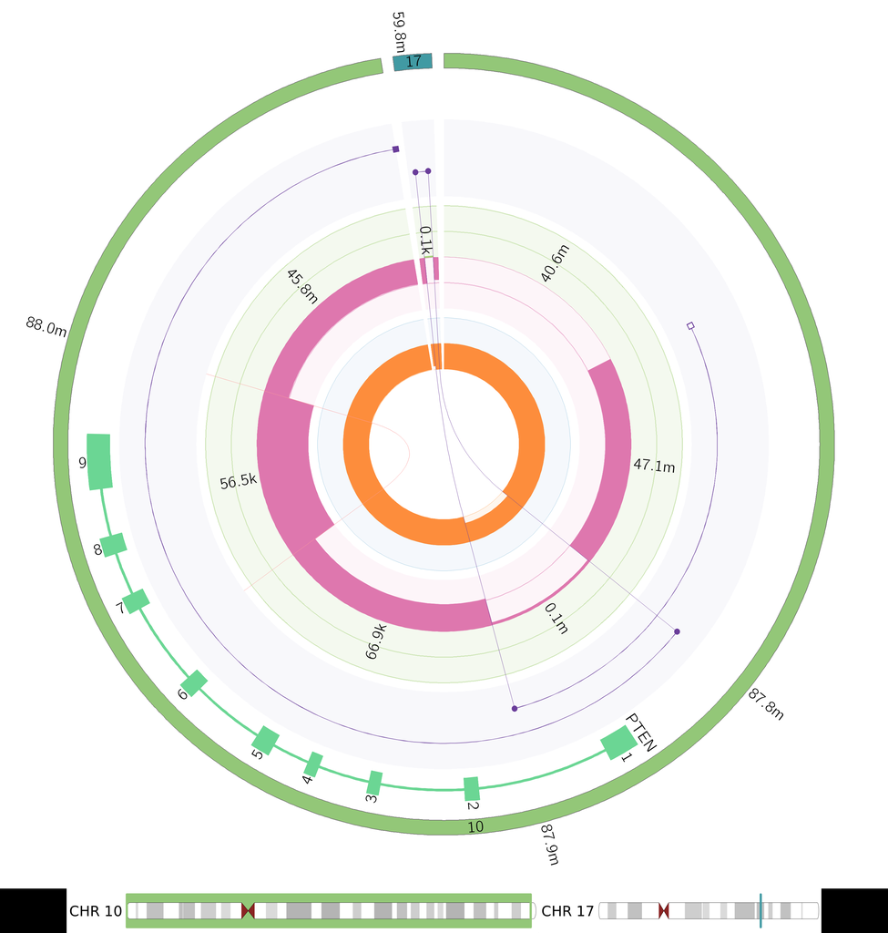

### chr17

nsegs: 5

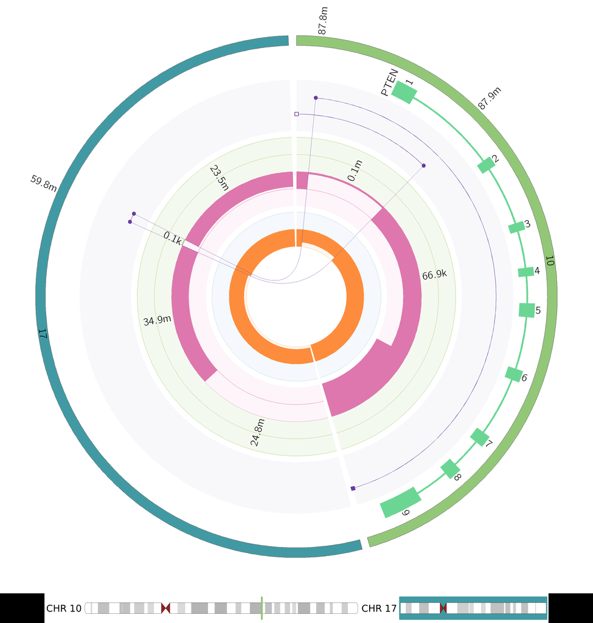

## Plots (Cluster)

**Total:** 2 cluster plots

### 0

clusterId: 0 | type: DUP | svId: 2 | nsegs: 5

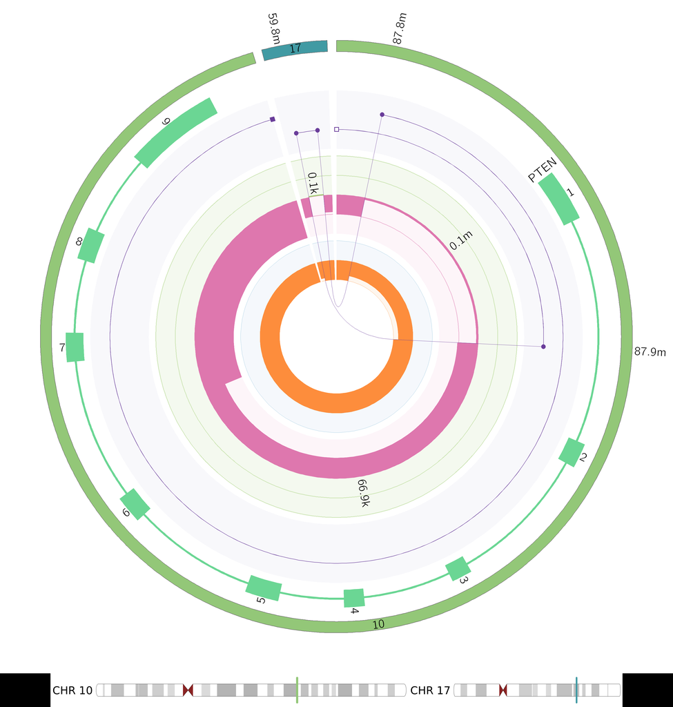

### 1

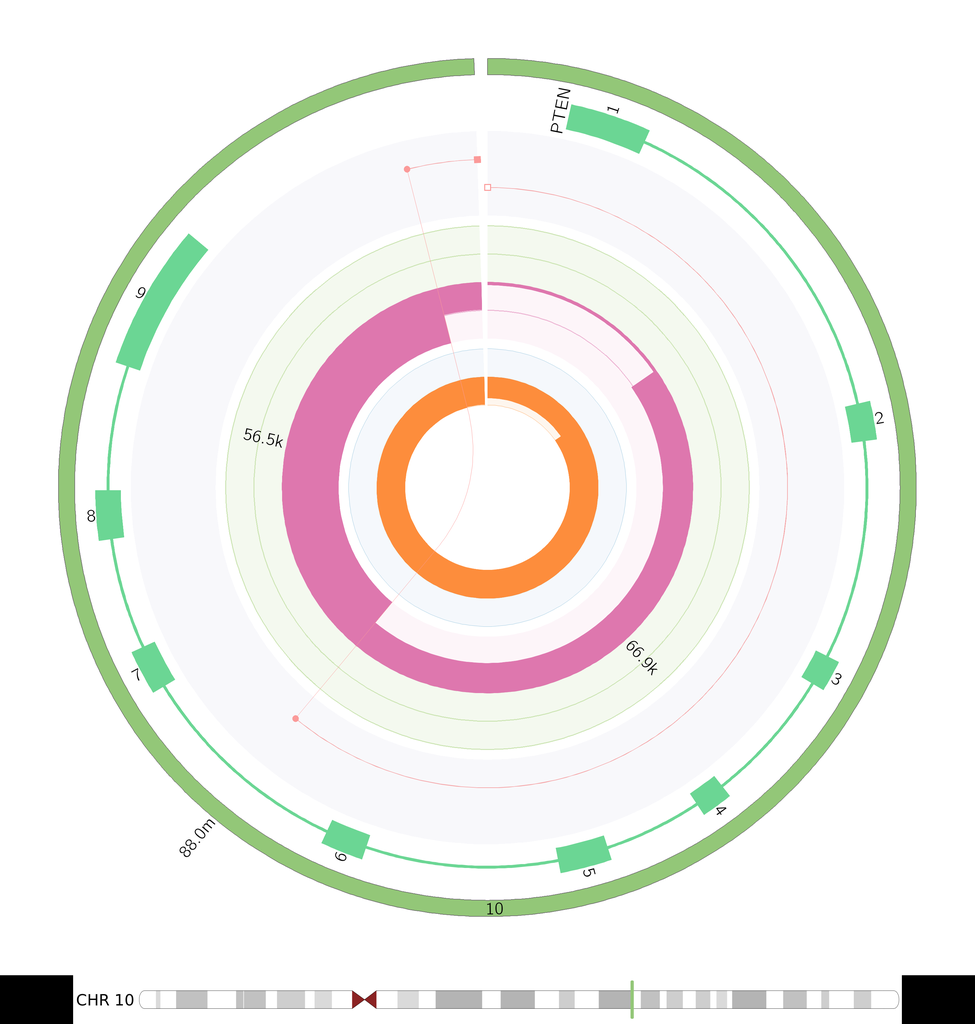

## Addendum

### Session Info

Platform information.

| name | value |
| --- | --- |
| version | R version 4.1.3 (2022-03-10) |
| os | Ubuntu 20.04.4 LTS |
| system | x86_64, linux-gnu |
| ui | X11 |
| language | (EN) |
| collate | C |
| ctype | C |
| tz | NA |
| date | 2022-06-15 |
| pandoc | 2.18 @ /opt/mambaforge/envs/gpgr_env/bin/ (via rmarkdown) |

### Report Inputs

| key | value |
| --- | --- |
| title | UMCCR LINX Report |
| table_dir | /Users/stephen/repos/nextflow_pipelines/hmftools/work/0d/7e147758911376f8140d2732f16aab/linx_annotation |
| plot_dir | /Users/stephen/repos/nextflow_pipelines/hmftools/work/77/9ad61ae066575090dc0fd6ba640645/linx_visualiser/plot |
| sample | SEQC-II_Tumor_50pc |